# Milwaukee Airport Flight Delay Analysis

By Gavin Jimenez, Ethan Nguyen, Julia Woods, Jinqing Su

## Introduction

Airplanes are heavily utilized by millions of Americans as a source of transportation for long distance travel. However, there are certain instances where flights are unexpectedly delayed, causing passengers to adjust their schedules at the last second. In this report, we examine the data of flights in 2015 flying out of the Milwaukee Airport to determine which airlines passengers should fly to best avoid the delays. We also look to discover what other factors might cause flight delays, including distance between airports and size of airports. An analysis of flight delay trends across different airlines demonstrates that Delta Airlines and US Airways are the two airlines with the least delays, and discovered that neither day of the week nor distance has a large effect on the number of delays.

## Background

Every year, the Department of Transportation’s (DOT) Bureau of Statistics records the time performance of domestic flights throughout the country in order to gather statistics regarding possible delays and cancellations. The DOT accesses this data from U.S. airlines’ reports of their flight data and compiles it into one dataset. We also incorporate a secondary dataset published by the FAA in our research. This dataset relates airport codes to the size of airports so we can draw conclusions about flight delays based on the size of an airport.

The key independent variables that we will use to examine these questions are the day of week of the flight, the airline identifier – a two letter code assigned by the FAA that identifies airlines, and the distance between the origin and destination airports, measured in miles. The key dependent variable that we will use is the arrival delay, or the difference between the actual arrival time and the scheduled arrival time, measured in minutes.

#### List of Key Variables:

- “Airline” (Airline Code)
- “Departure_delay” (Minutes)
- “Origin_airport” (Airport Code)
- “Scheduled_arrival” (Minutes)
- “Scheduled_departure” (Time of Day)
- “Arrival_time” (Time of Day)
- “Distance” (Miles)
- “Day of Week”
- “Destination_airport”
- “Arrival_delay” (Minutes)

#### Airline Abbreviations:

- UA = United Airlines
- AA = American Airlines
- US = US Airways
- F9 = Frontier Airlines
- B6 = JetBlue Airways
- OO = Skywest Airlines
- AS = Alaska Airlines
- NK = Spirit Airlines
- WN = Southwest Airlines
- DL = Delta Airlines
- EV = Atlantic Southeast Airlines
- HA = Hawaiian Airlines
- MQ = Envoy Airlines
- VX = Virgin America

## Analysis

#### Question 1: What airline can you fly on to avoid the most delays?

This bar graph highlights the differences between the airlines and how many flights they had in 2015 at the Milwaukee airport.

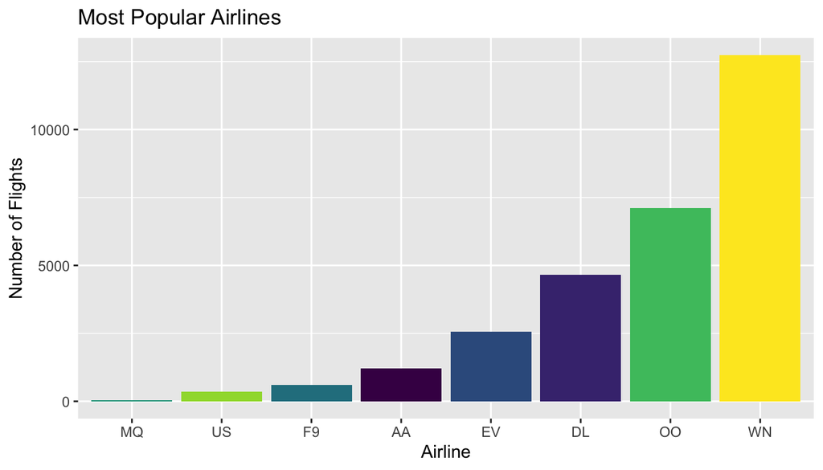

We can see that Southwest (WN) and Skywest (OO) are the most popular airlines. Envoy (MQ), US Airways (US), and Frontier (F9) are the least popular airlines. We need to consider how some of the airlines that have significantly less flights than the more popular airlines when interpreting our results and analyzing our data.

We then calculated the average departure delay and counted how many flights there were in 2015 for each airline. We plotted this on a scatter plot to see if there seemed to be any pattern.

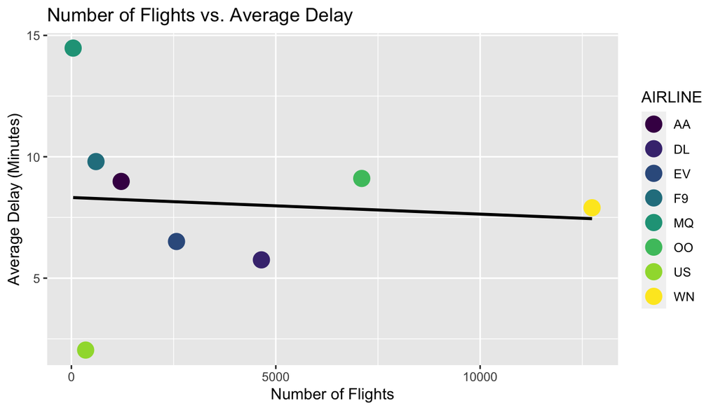

We can’t conclude any relationship from this plot, but it seems like in the first half of the graph there is a slight negative trend. This would show that the airlines with lower number of flights have higher average departure delays.

We created box plots for each airline to show the distribution of departure delays. There is a log scale on the y axis to make the graph more clear.

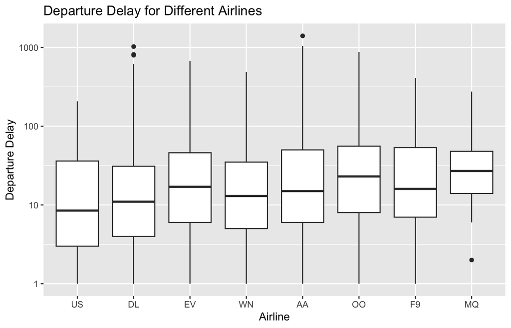

We wanted to conduct two hypothesis tests to help us answer our question about the best airline to fly with to avoid delays. Based on the above graphs, we chose to look at US Airways and Delta as they have the lowest median departure delays based on the box plot.

##### First Hypothesis Test:

For our hypothesis test, our population is flights leaving from Milwaukee Airport in 2015 and our sample is the flights leaving from Milwaukee in 2015. Our null hypothesis is that the true difference in mean departure delay time for US airways is the same as the mean departure delay time for all other airlines. Our alternative hypothesis is that the true difference in mean departure delay time for US airways is less than the mean departure delay time for all other airlines.

$$\begin{gather*}
\text{Let }\bar{x} \text{ be the average departure delay} \\
H_0: \bar{x}_{\text{us}} = \bar{x}_{\text{not us}} \\
H_1: \bar{x}_{\text{us}} < \bar{x}_{\text{not us}}
\end{gather*}$$

**Two Sample t-test**

| **T-Stat** | -4.4095 |
| --- | --- |
| **P-Value** | 6.802e-06 |
| **Df** | 369.68 |

Using t.test(), we found a p-value of 6.802e-06. This p value is very low and almost zero illustrating how there is strong evidence against the null hypothesis and in favor of the alternative hypothesis. This highlights that the difference in the mean departure delay between US Airlines and the other airlines is statistically significant.

##### Second Hypothesis Test:

For this hypothesis test, our null hypothesis is that the true difference in mean departure delay time for DL airways is the same as the mean departure delay time for all other airlines. Our alternative hypothesis is that the true difference in mean departure delay time for Delta airways is less than the mean departure delay time for all other airlines. We chose not to use data from US airways because we wanted to find the second best airline in terms of departure delay.

$$\begin{gather*}
\text{Let }\bar{x} \text{ be the average departure delay} \\
H_0: \bar{x}_{\text{DL}} = \bar{x}_{\text{not DL}} \\
H_1: \bar{x}_{\text{DL}} < \bar{x}_{\text{not DL}}
\end{gather*}$$

**Two Sample t-test**

| **T-Stat** | -3.921 |
| --- | --- |
| **P-Value** | 4.453e-05 |
| **Df** | 6566.7 |

Using t.test(), we found a p-value of 4.453e-05. This p value is very low and almost zero illustrating how there is strong evidence against the null hypothesis and in favor of the alternative hypothesis. This highlights that the difference in the mean departure delay between Delta Airlines (DL) and the other airlines is statistically significant.

#### Question 2: What might predict flight delays?

##### Distance

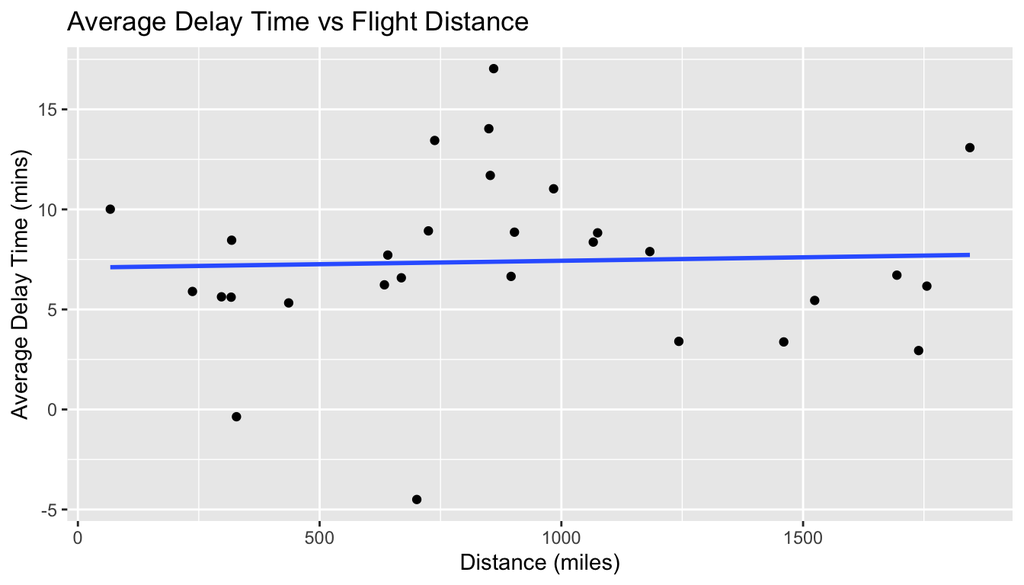

Based on this graph and the best fit line, there doesn’t seem to be a strong relationship between these two variables.

**Linear Model Generated w lm()**

[output not shown]

$$\begin{gather*}
\hat{y} = 7.0873759 + 0.0003447 \cdot x_0 \\
\end{gather*}$$

##### Day of the Week

Another variable we considered to predict flight delays was the day of the week. We plotted this with boxplots for each day of the week.

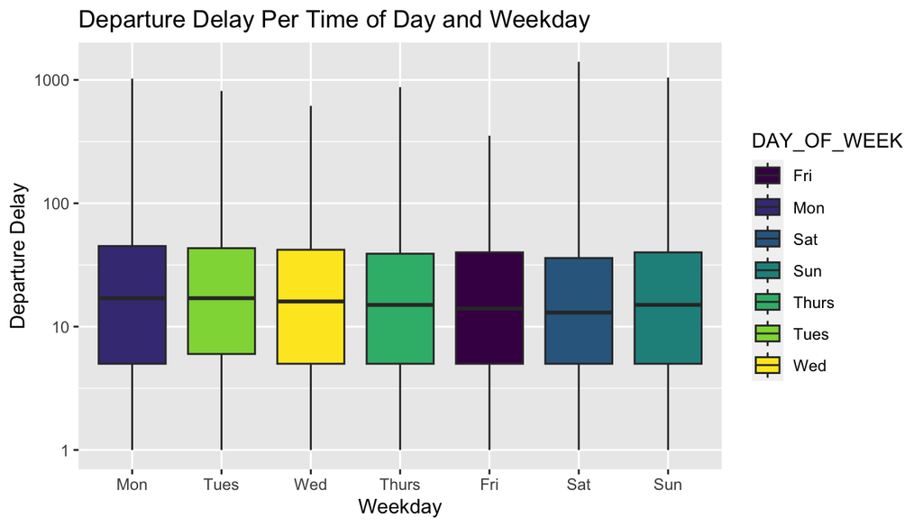

There doesn’t seem to be significant differences between the median days of the week, but that may be because of the log scale of the y-axis. Friday, Saturday, and Thursday seem to have the lowest median departure delays. Monday and Tuesday have the highest median departure delays. Saturday has the longest range with the highest maximum. Friday had the lowest range with the lowest maximum.

## Discussion

Some shortcomings of this analysis include the fact that some airlines have significantly less flights than others and therefore there is less data to analyze. For example, Envoy Air (MQ) is a regional airline, operating feeder flights for American Airlines, and runs much fewer flights than other larger airlines out of Milwaukee.

We may choose to analyze more recent data – for instance, US Airways was bought out by American, who probably runs more flights as a result, and therefore may suffer from different delays as a result. We may also choose to analyze flights from a different airport; we chose to analyze only flights from Milwaukee Airport to make the data file smaller and more manageable instead of analyzing a 500 MB file.

After analyzing the trends of flight delays across different airlines, we questioned whether these trends remain relevant in the present day. Since this data was collected for the year of 2015, there is the possibility that the efficiency of each airline might be altered years later. However, we still hypothesize the conclusions that we have made still remain accurate for present day air travel out of Milwaukee.

In summary, from the data that we analyzed, we conclude that Delta and US Airways were the airlines who, on average, suffered the least delay when flying out of Milwaukee.

## References

[^1]

[^2]

[^1]: https://www.kaggle.com/datasets/usdot/flight-delays?select=airlines.csv
[^2]: https://www.faa.gov/airports/planning_capacity/npias/current/